# Homework 3 HDS 823, Multiple Correspondence Analysis - Titanic.

This analysis performed in R, using the FactoMineR library.

Kyle P. Rasku RN BSN

In RStudio, you can execute each chunk by clicking the *Run* button within the chunk or by placing your cursor inside it and pressing *Ctrl+Shift+Enter*.

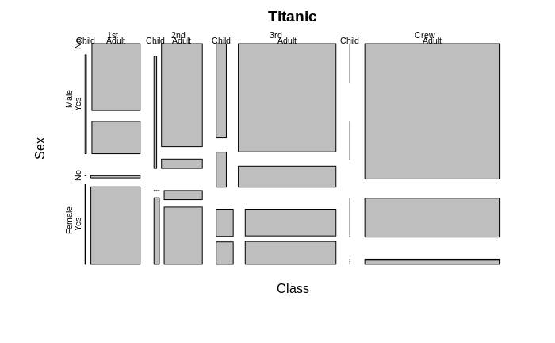

```r
plot(Titanic)
```

Titanic Data Set - Modified for MCA by Nick Buonomia  
Perform Multiple Correspondence Analysis of Class, Age & Sex with Supplemental Variable: Survived

```r
library("FactoMineR")
library("factoextra")
titanic <- read.csv("titanic_MCA.csv")
titanic.active <- titanic[1:2200, 2:5]
head(titanic.active[, 1:4], 10)
```

|  | Class | Age | Sex | Survived |
| --- | --- | --- | --- | --- |
| 1 | first | adult | male | yes |
| 2 | first | adult | male | yes |
| 3 | first | adult | male | yes |
| 4 | first | adult | male | yes |
| 5 | first | adult | male | yes |
| 6 | first | adult | male | yes |
| 7 | first | adult | male | yes |
| 8 | first | adult | male | yes |
| 9 | first | adult | male | yes |
| 10 | first | adult | male | yes |

Active Rows for MCA are set.  
Provide data summary of active rows:

```r
summary(titanic.active)[, 1:4]
```

```
    Class               Age                Sex              Survived
 Length:2200        Length:2200        Length:2200        Length:2200
 Class :character   Class :character   Class :character   Class :character
 Mode  :character   Mode  :character   Mode  :character   Mode  :character
```

This data set has 2,200 rows and all variables are categorical.  
Plot frequencies:

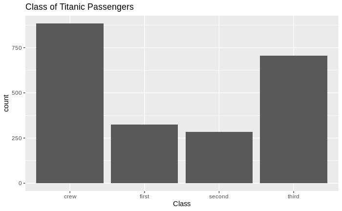

```r
library(ggplot2)
ggplot(titanic.active, aes(x = Class)) + geom_bar() + labs(title = "Class of Titanic Passengers")
```

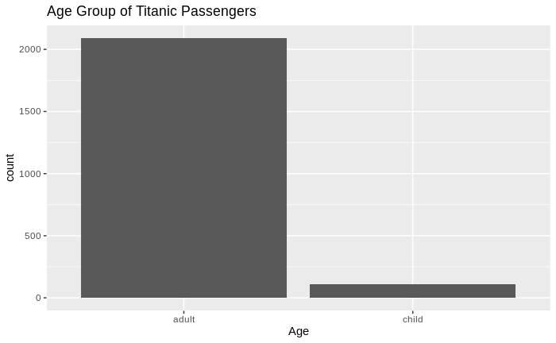

```r
ggplot(titanic.active, aes(x = Age)) + geom_bar() + labs(title = "Age Group of Titanic Passengers")
```

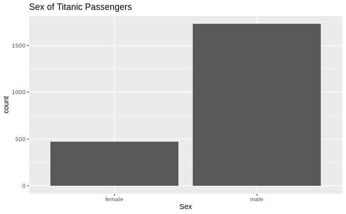

```r
ggplot(titanic.active, aes(x = Sex)) + geom_bar() + labs(title = "Sex of Titanic Passengers")
```

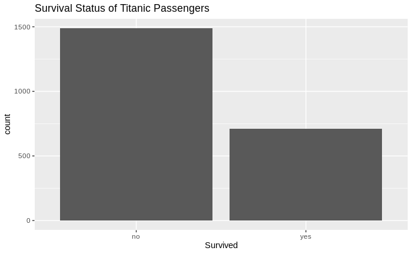

```r
ggplot(titanic.active, aes(x = Survived)) + geom_bar() + labs(title = "Survival Status of Titanic Passengers")
```

Looking more closely at Children:

```r
children <- subset(titanic, Age=="child")
nrow(children)
```

```
[1] 109
```

There are 109 children out of 2200 people, or 5% of all the passengers.  
How many Children Survived by Class?

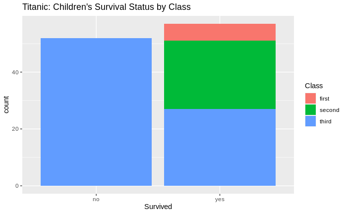

```r
ggplot(data = children, aes(x = Survived, fill = Class)) +
    geom_bar() + labs(title = "Titanic: Children's Survival Status by Class")
```

```r
library(sqldf)
num_died <- sqldf('SELECT count(*) from children where Survived="no"')
num_third_survived <- sqldf('SELECT count(*) from children where Survived="yes" and Class="third"')
num_second_survived <- sqldf('SELECT count(*) from children where Survived="yes" and Class="second"')
num_first_survived <- sqldf('SELECT count(*) from children where Survived="yes" and Class="first"')
num_third_children = num_died + num_third_survived
```

Number of First Class Children on Board: 6, Survived: 6  
Number of Second Class Children on Board: 24, Survived: 24  
Number of Third Class Children on Board: 79, Survived: 27 (34.18%)

While there were fewer children on board with parents holding First and Second Class tickets, and many more with parents holding Third Class tickets, 100% of the children with parents holding First and Second class tickets survived the sinking, while only about 34% of the children with parents holding Third Class tickets survived the sinking.

```r
# Perform MCA, only active variables: Class, Sex and Age
# The SUPPLEMENTAL variable is "Survived"
# Use the "Burt" method for calculation (per Nick)
res.mca <- MCA(titanic.active, quali.sup=4, method="burt", graph = FALSE)
res.mca
```

```
**Results of the Multiple Correspondence Analysis (MCA)**
The analysis was performed on 2200 individuals, described by 4 variables
*The results are available in the following objects:

   name                description
1  "$eig"              "eigenvalues"
2  "$var"              "results for the variables"
3  "$var$coord"        "coord. of the categories"
4  "$var$cos2"         "cos2 for the categories"
5  "$var$contrib"      "contributions of the categories"
6  "$var$v.test"       "v-test for the categories"
7  "$ind"              "results for the individuals"
8  "$ind$coord"        "coord. for the individuals"
9  "$ind$cos2"         "cos2 for the individuals"
10 "$ind$contrib"      "contributions of the individuals"
11 "$quali.sup"        "results for the supplementary categorical variables"
12 "$quali.sup$coord"  "coord. for the supplementary categories"
13 "$quali.sup$cos2"   "cos2 for the supplementary categories"
14 "$quali.sup$v.test" "v-test for the supplementary categories"
15 "$call"             "intermediate results"
16 "$call$marge.col"   "weights of columns"
17 "$call$marge.li"    "weights of rows"
```

Intermediate Results:

```r
# Commented out - this does include the Burt Tables, but it is about 100 pages long.
#res.mca$call
```

The proportions of variance retained by the different dimensions, extracted to Eigenvalues:

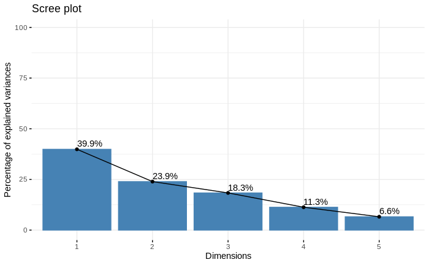

```r
eig.val <- get_eigenvalue(res.mca)
fviz_screeplot(res.mca, addlabels = TRUE, ylim = c(0, 99))
```

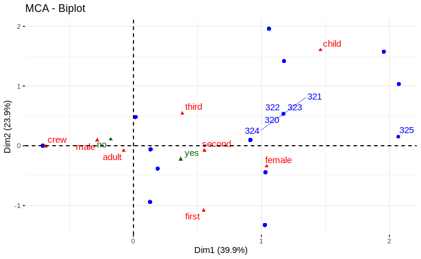

```r
# This should be quite messy, with 2200 individuals...
# There were so many overlapping data points that the library chose not to show them
fviz_mca_biplot(res.mca,
               repel = TRUE, # Avoid text overlapping (slow if many point)
               ggtheme = theme_minimal())
```

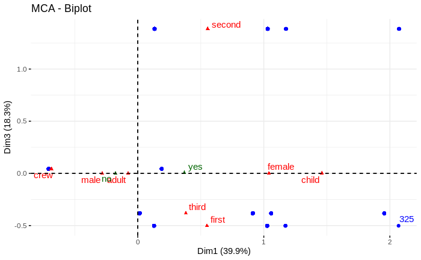

```r
# Now let's look at Dimensions 1 and 3
fviz_mca_biplot(res.mca,
                axes = c(1,3),
               repel = TRUE, # Avoid text overlapping (slow if many point)
               ggtheme = theme_minimal())
```

Hmm…ok. So Here we have the crew and children at polar opposite extremes. And on Dim3, first and third class are at the bottom of Dim3 while second class if very far away near the top.

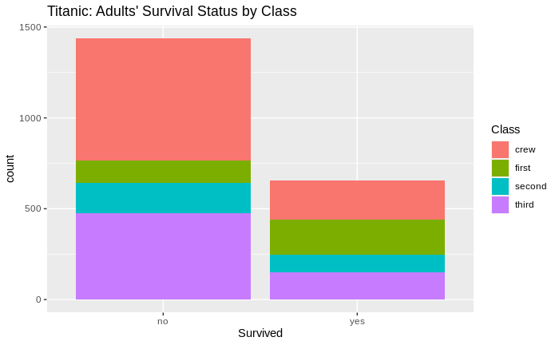

```r
adults <- subset(titanic, Age=="adult")
ggplot(data = adults, aes(x = Survived, fill = Class)) +
    geom_bar() + labs(title = "Titanic: Adults' Survival Status by Class")
```

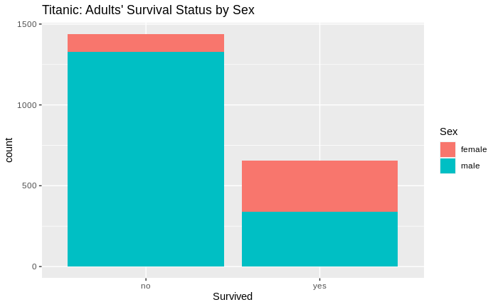

```r
ggplot(data = adults, aes(x = Survived, fill = Sex)) +
    geom_bar() + labs(title = "Titanic: Adults' Survival Status by Sex")
```

```r
num_adults_died <- sqldf('SELECT count(*) from adults where Survived="no"')
num_adults_lived <- sqldf('SELECT count(*) from adults where Survived="yes"')
num_tadults_survived <- sqldf('SELECT count(*) from adults where Survived="yes" and Class="third"')
num_tadults_died <- sqldf('SELECT count(*) from adults where Survived="no" and Class="third"')
num_sadults_survived <- sqldf('SELECT count(*) from adults where Survived="yes" and Class="second"')
num_sadults_died <- sqldf('SELECT count(*) from adults where Survived="no" and Class="second"')
num_fadults_survived <- sqldf('SELECT count(*) from adults where Survived="yes" and Class="first"')
num_fadults_died <- sqldf('SELECT count(*) from adults where Survived="no" and Class="first"')
num_tadults = num_tadults_survived + num_tadults_died
num_sadults = num_sadults_survived + num_sadults_died
num_fadults = num_fadults_survived + num_fadults_died
```

**There were 2092 adults on board Titanic.**  
1438 adults died (68.74%), 654 (31.26%) survived.  
There were 319 adults in first class. 197 of them (62%) survived.  
There were 261 adults in second class. 94 of them (36%) survived.  
There were 627 adults in third class. 151 of them (24%) survived.

```r
num_ffemales <- sqldf('SELECT count(*) from adults where Sex="female" and Class="first"')
num_ffemales_survived <- sqldf('SELECT count(*) from adults where Sex="female" and Class="first" and Survived="yes"')
num_sfemales <- sqldf('SELECT count(*) from adults where Sex="female" and Class="second"')
num_sfemales_survived <- sqldf('SELECT count(*) from adults where Sex="female" and Class="second" and Survived="yes"')
num_tfemales <- sqldf('SELECT count(*) from adults where Sex="female" and Class="third"')
num_tfemales_survived <- sqldf('SELECT count(*) from adults where Sex="female" and Class="third" and Survived="yes"')
num_cfemales <- sqldf('SELECT count(*) from adults where Sex="female" and Class="crew"')
num_cfemales_survived <- sqldf('SELECT count(*) from adults where Sex="female" and Class="crew" and Survived="yes"')
```

**There were 144 women traveling first class, and 140 of them survived the sinking (97%).**  
As we know from before, 100% of the first class children survived (but there were only 6, according to this data set).  
There were 93 women traveling second class, and 80 of them survived (86%).  
Again, all the second class children survived.  
There were 165 women traveling third class, and 76 of them survived (46%). And 34% of their children (calculated earlier).  
While the crew fared poorly in general in terms of survival, there were only 23 women on the crew, and 20 of them survived (87%).

```r
# Looking at the coordinates, cos2 and contribution of variable categories
var <- get_mca_var(res.mca)
var
```

```
Multiple Correspondence Analysis Results for variables
 ===================================================
  Name       Description
1 "$coord"   "Coordinates for categories"
2 "$cos2"    "Cos2 for categories"
3 "$contrib" "contributions of categories"
```

The correlation between variables and principal dimensions:

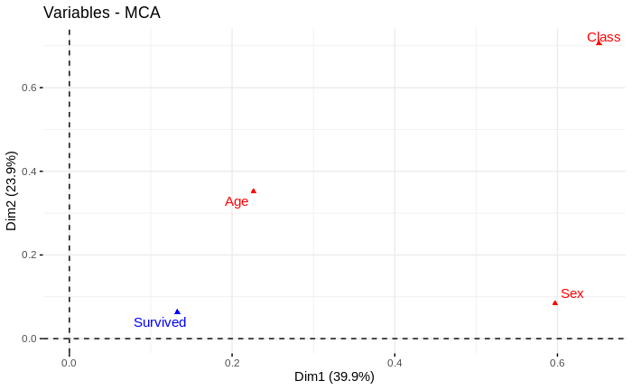

```r
fviz_mca_var(res.mca, choice = "mca.cor",
            repel = TRUE, # Avoid text overlapping (slow)
            ggtheme = theme_minimal())
```

Class contributes strongly to both Dim 1 and 2. Sex contributes strongly to Dim 1 but NOT Dim 2. Age is a moderate contributor to both Dim 1 and Dim 2 and Survived is more of a contributor to Dim 1 than 2.

```r
# Category / Value Coordinates
round(var$coord, 2)
```

```
       Dim 1 Dim 2 Dim 3 Dim 4 Dim 5
crew   -0.69 -0.01  0.04  0.17  0.29
first   0.55 -1.09 -0.50  0.44 -0.34
second  0.55 -0.08  1.38 -0.10 -0.24
third   0.38  0.54 -0.38 -0.38 -0.11
adult  -0.08 -0.08  0.00 -0.08  0.00
child   1.46  1.60  0.00  1.45  0.08
female  1.04 -0.34  0.00 -0.16  0.46
male   -0.28  0.09  0.00  0.04 -0.13
```

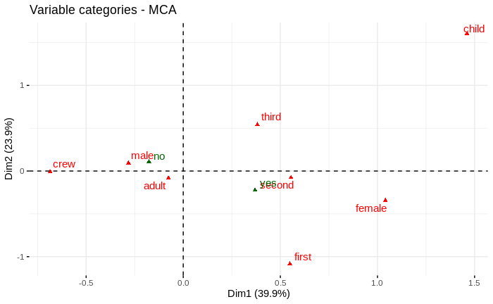

```r
# Visualizing Category / Value Coordinates
fviz_mca_var(res.mca,
             repel = TRUE, # Avoid text overlapping (slow)
             ggtheme = theme_minimal())
```

Degrees of association between variable categories and axes:

```r
head(var$cos2, 10)
```

```
           Dim 1        Dim 2        Dim 3       Dim 4        Dim 5
crew   0.8045008 0.0001163271 3.251087e-03 0.050969692 0.1411620606
first  0.1478079 0.5780531707 1.235559e-01 0.095184209 0.0553988237
second 0.1339680 0.0026007050 8.343042e-01 0.003940801 0.0251863344
third  0.1965379 0.3951209036 1.974787e-01 0.195201720 0.0156607115
adult  0.3130468 0.3770377740 6.117649e-28 0.308988289 0.0009271487
child  0.3130468 0.3770377740 8.214726e-28 0.308988289 0.0009271487
female 0.7508468 0.0821925641 1.616615e-30 0.017879783 0.1490808967
male   0.7508468 0.0821925641 6.034649e-30 0.017879783 0.1490808967
```

Dim 1 is representing the crew, a small equalish amt of all 3 classes, about equal amounts of adults & children, males & females.  
Dim 2 is representing first class, and a good chunk of third class. Also some more adults and children.  
Dim 3 is a hodgepodge with lion’s share of second class, but there’s not much there (large negative exp values).  
Dim 4 is a bit more of third class, more of the variance of adults & children.  
Dim 5 is the rest of the crew and males & females.

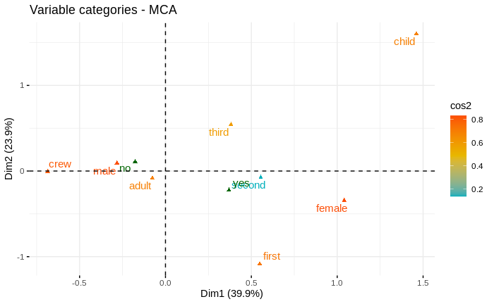

```r
# Color by cos2 values: quality on the factor map
fviz_mca_var(res.mca, col.var = "cos2",
             gradient.cols = c("#00AFBB", "#E7B800", "#FC4E07"),
             repel = TRUE, # Avoid text overlapping
             ggtheme = theme_minimal())
```

The lower quality of the Second class and - to a smaller extent - Third class data points is reiterated above.

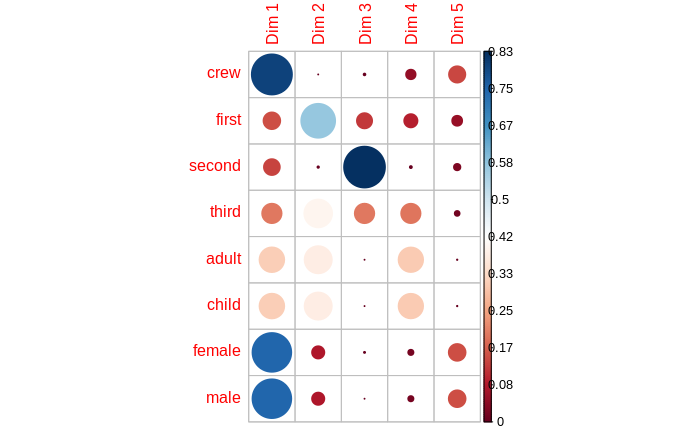

```r
library("corrplot")
corrplot(var$cos2, is.corr=FALSE)
```

Another view of this with corrplot library.  
If we want to get a good look at survival vv. Second class, we may need to look beyond Dims 1 & 2.

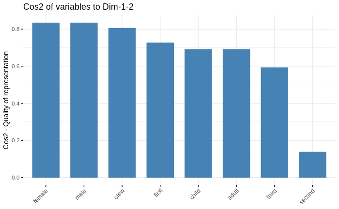

```r
# Cos2 of variable categories on Dim.1 and Dim.2
fviz_cos2(res.mca, choice = "var", axes = 1:2)
```

```r
# Contributions of Variable Categories to the Dimensions
head(round(var$contrib,2), 10)
```

```
       Dim 1 Dim 2 Dim 3 Dim 4 Dim 5
crew   26.05  0.01  0.23  5.83 27.69
first   6.14 40.01 11.16 13.98 13.94
second  5.50  0.18 74.52  0.57  6.27
third   6.45 21.61 14.09 22.65  3.11
adult   0.76  1.53  0.00  2.65  0.01
child  14.59 29.28  0.00 50.91  0.26
female 31.86  5.81  0.00  2.68 38.32
male    8.63  1.57  0.00  0.73 10.38
```

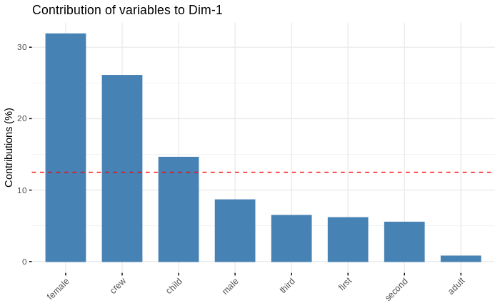

```r
# Contributions of rows to dimension 1
fviz_contrib(res.mca, choice = "var", axes = 1, top = 15)
```

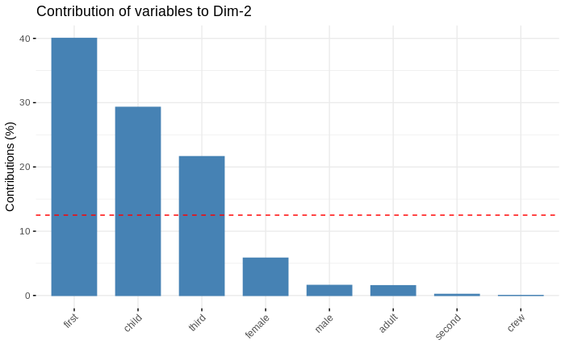

```r
# Contributions of rows to dimension 2
fviz_contrib(res.mca, choice = "var", axes = 2, top = 15)
```

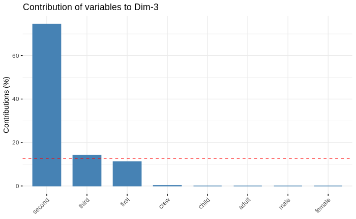

```r
# Contributions of rows to dimension 3
fviz_contrib(res.mca, choice = "var", axes = 3, top = 15)
```

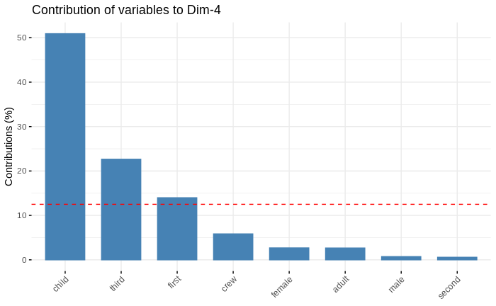

```r
# Contributions of rows to dimension 4
fviz_contrib(res.mca, choice = "var", axes = 4, top = 15)
```

The red dashed line on the graphs above indicates the *expected average value*, if the contributions were uniform.

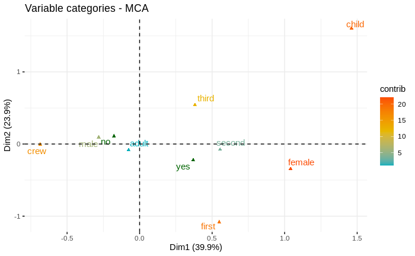

```r
fviz_mca_var(res.mca, col.var = "contrib",
             gradient.cols = c("#00AFBB", "#E7B800", "#FC4E07"),
             repel = TRUE, # avoid text overlapping (slow)
             ggtheme = theme_minimal()
             )
```

Graphing Individuals

```r
ind <- get_mca_ind(res.mca)
ind
```

```
Multiple Correspondence Analysis Results for individuals
 ===================================================
  Name       Description
1 "$coord"   "Coordinates for the individuals"
2 "$cos2"    "Cos2 for the individuals"
3 "$contrib" "contributions of the individuals"
```

Quality and Contribution of Individuals

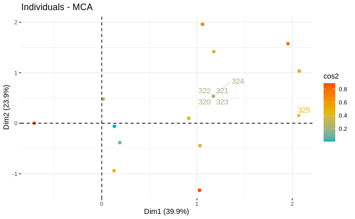

```r
fviz_mca_ind(res.mca, col.ind = "cos2",
             gradient.cols = c("#00AFBB", "#E7B800", "#FC4E07"),
             repel = TRUE, # Avoid text overlapping (slow if many points)
             ggtheme = theme_minimal())
```

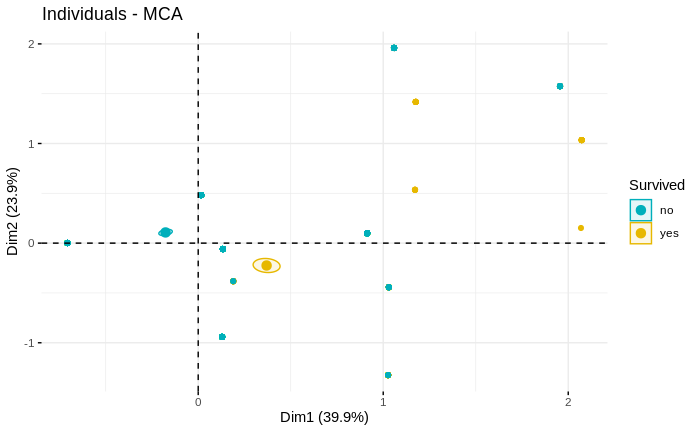

```r
# Apply SURVIVED as Grouping Variable
fviz_mca_ind(res.mca,
             label = "none", # hide individual labels
             habillage = "Survived", # color by groups
             palette = c("#00AFBB", "#E7B800"),
             addEllipses = TRUE, ellipse.type = "confidence",
             ggtheme = theme_minimal())
```

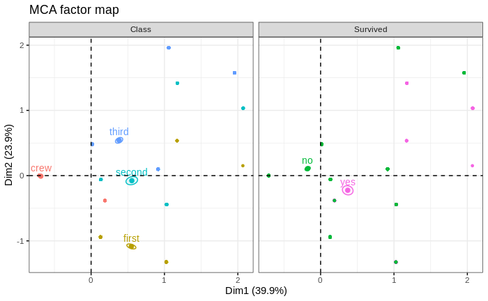

```r
fviz_ellipses(res.mca, c("Survived", "Class"),
              geom = "point")
```

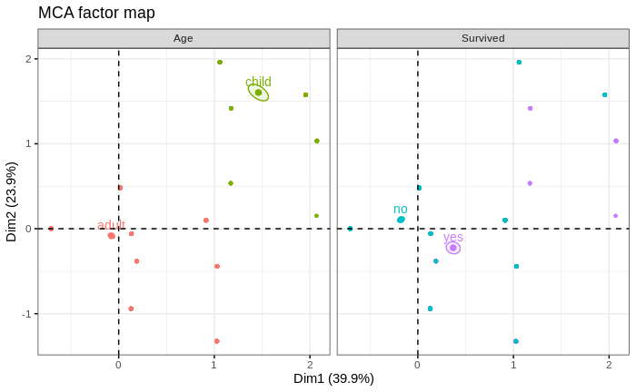

```r
fviz_ellipses(res.mca, c("Survived", "Age"),
              geom = "point")
```

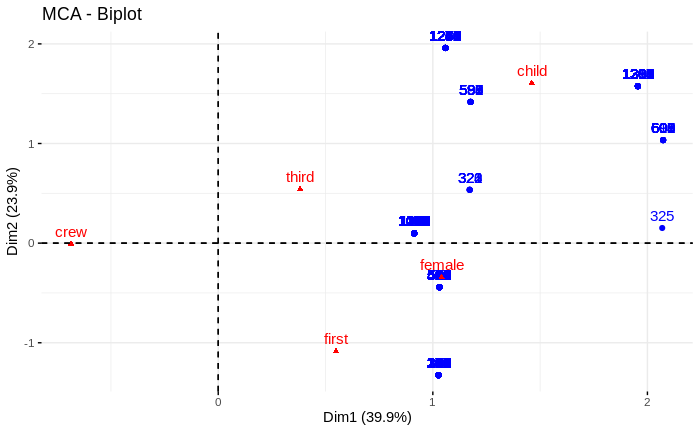

```r
# top 500 contributing individuals and top 5 variable categories
fviz_mca_biplot(res.mca, select.ind = list(contrib = 500),
               select.var = list(contrib = 5),
               ggtheme = theme_minimal())
```

**All in all, the MCA concludes clearly that Men, Crew members and Adults in general were less likely to survive, while Females, Children and First class passengers were much more likely.**